# Exploratory analysis of Italian cafes names

Stefano De Sabbata

2022-04-09 20:18:37

## Aims

Work in progress! :sweat_smile:

The aim is to conduct an analysis similar to the work presented by Chris Brunsdon, Paul Harris and Lex Comber at [GIRSRUK 2022](http://liverpool.gisruk.org/), in the paper [*“A Spatial Analysis of British Public House Names”*](https://doi.org/10.5281/zenodo.6410180), but focusing on *Italian “cafes”*. However, for a number of cultural and historical reasons, *Italian “cafes”* can be understood and encoded in OpenStreetMap (the data source for this project) as: `amenity => cafe`, `amenity => bar`, `shop => bakery`, `shop => confectionery`, `shop => chocolate`, `amenity => ice_cream` or `shop => ice_cream`. This will definitely need to be discussed here at some point – likely, this has already been discussed somewhere else.

## Preparation

### Libraris

```r
library(tidyverse)
library(magrittr)
library(knitr)
library(sf)
library(tmap)
#library(ggmap)
library(leaflet)
library(tidytext)
```

### Data

This analysis uses OpenStreetMap open data, licensed under the Open Data Commons Open Database License (ODbL) by the OpenStreetMap Foundation (OSMF) © OpenStreetMap contributors.

```r
barcafes_Italy <- read_sf("../data/bar-cafe-etc-Italy-2022-04-09-19-36-39.geojson")
```

### Overview map

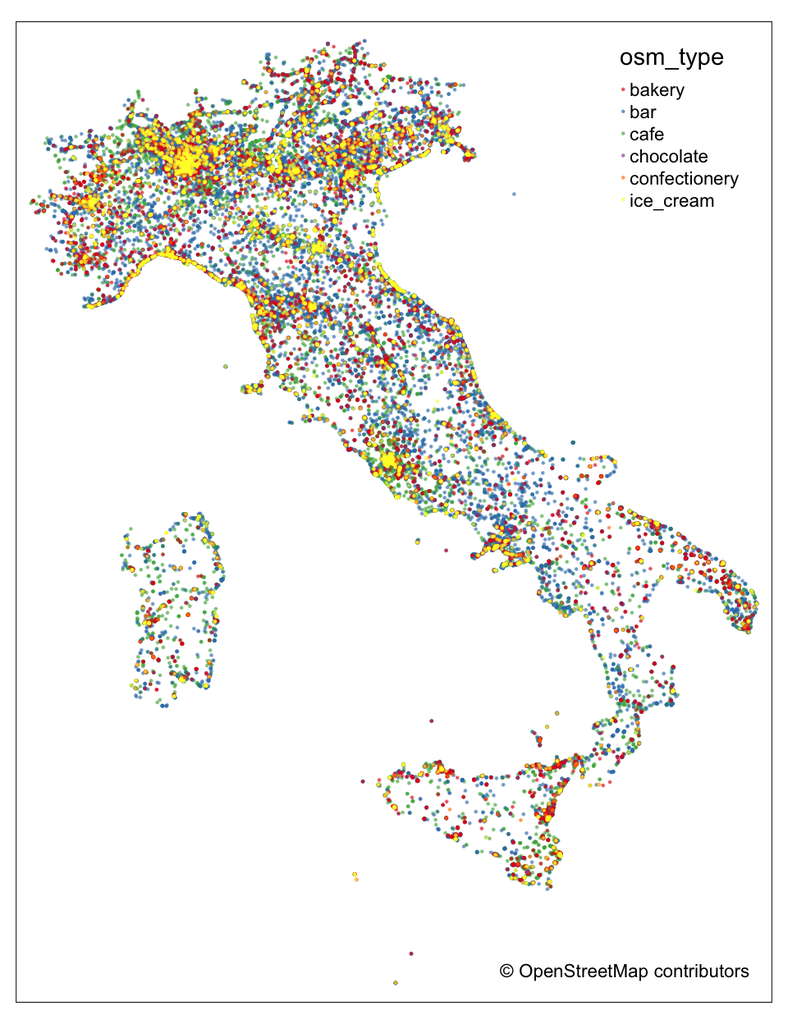

```r
tm_shape(barcafes_Italy) +
  tm_dots("osm_type", size= 0.01, alpha = 0.5, palette = "Set1") +
  tm_credits("© OpenStreetMap contributors")
```

## Text content overview

```r
stop_words_it <- tibble(
  word = stopwords::stopwords("it", source = "snowball"),
  lexicon = "snowball"
)
```

```r
barcafes_Italy_name_tokens <-
  barcafes_Italy %>%
  st_drop_geometry() %>%
  filter(!is.na(name)) %>%
  unnest_tokens(word, name)
```

Most common words in *Italian “cafes”* names.

```r
barcafes_Italy_name_tokens %>%
  anti_join(stop_words_it) %>%
  count(word, sort = TRUE) %>%
  slice_max(order_by = n, n = 100) %>%
  kable()
```

| word | n |
| --- | --- |
| bar | 14482 |
| caffè | 3634 |
| gelateria | 2009 |
| cafè | 1727 |
| panificio | 1717 |
| pasticceria | 1495 |
| caffetteria | 981 |
| café | 734 |
| pane | 722 |
| forno | 718 |
| cafe | 663 |
| centrale | 481 |
| gelato | 457 |
| caffe | 451 |
| caffé | 439 |
| san | 419 |
| dolce | 405 |
| circolo | 390 |
| panetteria | 387 |
| sport | 316 |
| gran | 258 |
| coffee | 255 |
| chiosco | 243 |
| bottega | 241 |
| roma | 238 |
| de | 230 |
| antico | 220 |
| osteria | 213 |
| casa | 211 |
| corso | 210 |

[output cut: 70 more lines]

## Name components’ odds ratio

In order to explore how specific to each area a part of a name is, I start by following the approach used by Shelton et al. (2014), calculating the odd-ratio (or location quotient) for each word and area, unsing a 10km hexagonal grid.

```r
hex_gird <- read_sf("../data/hexagonal_grid_10km_Italy.geojson")
```

```r
barcafes_Italy_with_hex <-
  barcafes_Italy %>%
  st_join(hex_gird)
```

```r
barcafes_Italy_with_hex_tokens <-
  barcafes_Italy_with_hex %>%
  st_drop_geometry() %>%
  filter(!is.na(name)) %>%
  unnest_tokens(word, name) %>%
  anti_join(stop_words_it) %>%
  count(hex_id, word, sort = TRUE) %>%
  complete(hex_id, word, fill = list(n = 0))
sum_hex <- barcafes_Italy_with_hex_tokens %>% count(hex_id, wt = n) %>% rename(sum_hex = n)
sum_word <- barcafes_Italy_with_hex_tokens %>% count(word, wt = n) %>% rename(sum_word = n)
sum_all_value <- barcafes_Italy_with_hex_tokens %>% count(wt = n) %>% pull(n)

barcafes_Italy_with_hex_oddratios <-
  barcafes_Italy_with_hex_tokens %>%
  left_join(sum_hex) %>%
  left_join(sum_word) %>%
  mutate(sum_all = sum_all_value) %>%
  mutate(
    oddratio = ((n / sum_word) / (sum_hex / sum_all))
  ) %>%
  mutate(
    oddratio_lower =
      exp(
        log(oddratio) -
          (3.29 * sqrt(
            (1/n) + (1/sum_word) + (1/sum_hex) + (1/sum_all)
          ))
      )
  )
```

Odds ratio base descriptive statistics for top name components.

```r
barcafes_Italy_name_tokens %>%
  anti_join(stop_words_it) %>%
  count(word, sort = TRUE) %>%
  slice_max(order_by = n, n = 100) %>%
  left_join(
    barcafes_Italy_with_hex_oddratios %>%
      group_by(word) %>%
      summarise(
        oddratio_min = min(oddratio),
        oddratio_mean = mean(oddratio),
        oddratio_median = median(oddratio),
        oddratio_max = max(oddratio),
        oddratio_sd = sd(oddratio)
      )
  ) %>%
  kable()
```

| word | n | oddratio_min | oddratio_mean | oddratio_median | oddratio_max | oddratio_sd |
| --- | --- | --- | --- | --- | --- | --- |
| bar | 14482 | 0 | 1.2284777 | 1.089488 | 6.882751 | 1.014686 |
| caffè | 3634 | 0 | 0.7023985 | 0.000000 | 27.428729 | 1.570688 |
| gelateria | 2009 | 0 | 0.8246932 | 0.000000 | 49.614734 | 2.480577 |
| cafè | 1727 | 0 | 0.6345525 | 0.000000 | 28.858135 | 2.002414 |
| panificio | 1717 | 0 | 0.9857959 | 0.000000 | 58.052417 | 2.843662 |
| pasticceria | 1495 | 0 | 0.8584574 | 0.000000 | 66.672910 | 2.704440 |
| caffetteria | 981 | 0 | 0.6905493 | 0.000000 | 101.606524 | 3.401239 |
| café | 734 | 0 | 0.7523636 | 0.000000 | 67.899183 | 3.595124 |
| pane | 722 | 0 | 0.7859114 | 0.000000 | 69.027701 | 3.610254 |
| forno | 718 | 0 | 1.0918495 | 0.000000 | 69.412256 | 4.406908 |
| cafe | 663 | 0 | 0.8766593 | 0.000000 | 50.113625 | 4.004653 |
| centrale | 481 | 0 | 1.9953114 | 0.000000 | 207.226611 | 9.779693 |
| gelato | 457 | 0 | 0.5739907 | 0.000000 | 54.527352 | 3.022671 |
| caffe | 451 | 0 | 0.9923864 | 0.000000 | 110.505543 | 5.991289 |
| caffé | 439 | 0 | 0.7588845 | 0.000000 | 113.526196 | 4.390049 |
| san | 419 | 0 | 0.7977560 | 0.000000 | 118.945107 | 4.673237 |
| dolce | 405 | 0 | 0.6567357 | 0.000000 | 123.056790 | 4.055295 |
| circolo | 390 | 0 | 1.7792246 | 0.000000 | 255.579487 | 10.746292 |
| panetteria | 387 | 0 | 0.9252028 | 0.000000 | 73.588778 | 4.979438 |
| sport | 316 | 0 | 2.0721072 | 0.000000 | 157.715190 | 11.010563 |
| gran | 258 | 0 | 0.8685035 | 0.000000 | 193.170543 | 7.496501 |
| coffee | 255 | 0 | 0.6942017 | 0.000000 | 195.443137 | 6.373547 |
| chiosco | 243 | 0 | 1.6075222 | 0.000000 | 410.189300 | 13.634260 |
| bottega | 241 | 0 | 0.7787468 | 0.000000 | 206.796681 | 7.141670 |
| roma | 238 | 0 | 1.4062811 | 0.000000 | 418.806723 | 12.071688 |
| de | 230 | 0 | 0.8967553 | 0.000000 | 216.686957 | 6.917986 |
| antico | 220 | 0 | 0.8174123 | 0.000000 | 151.024242 | 6.526413 |
| osteria | 213 | 0 | 1.3240948 | 0.000000 | 233.981221 | 10.716209 |
| casa | 211 | 0 | 0.9053867 | 0.000000 | 236.199052 | 7.775116 |
| corso | 210 | 0 | 1.1927584 | 0.000000 | 237.323810 | 9.004598 |

[output cut: 70 more lines]

## Term-specific maps

### Pasticceria

```r
leaflet(
    barcafes_Italy %>%
    filter(
      name %>%
        str_to_lower() %>%
        str_detect("pasticceria")
    )
  ) %>%
  addTiles() %>%
  addProviderTiles(providers$Stamen.Toner) %>%
  addCircleMarkers(
    radius = 5,
    color = "red",
    popup = ~as.character(name),
    label = ~as.character(name)
  )
```

[interactive chart not shown]

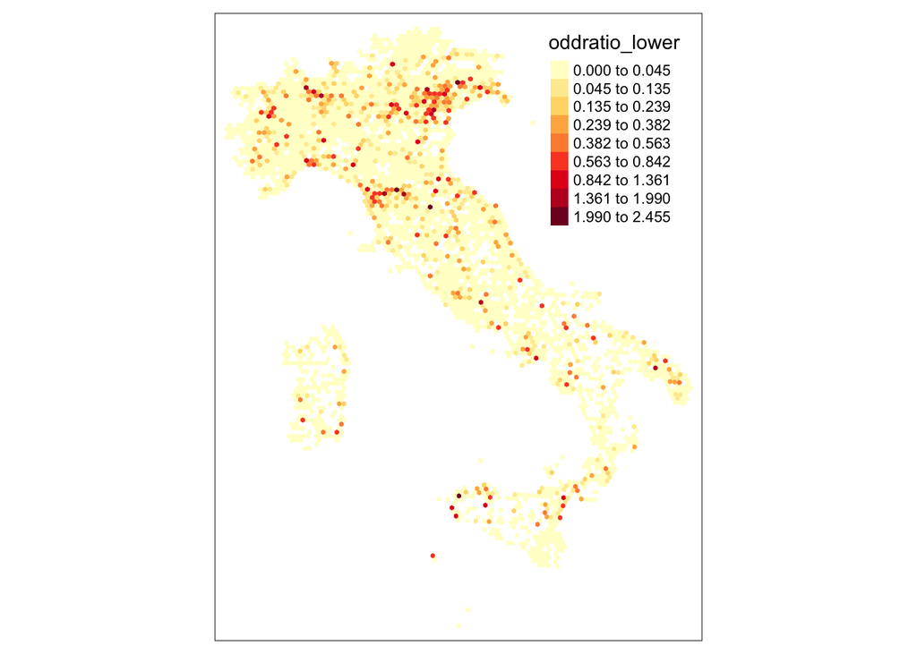

```r
# tm_shape(boundary_Italy) +
#   tm_borders() +
tm_shape(
    hex_gird %>%
      inner_join(
        barcafes_Italy_with_hex_oddratios %>%
          filter(word == "pasticceria")
      )
  ) +
  tm_fill(
    "oddratio_lower",
    showNA = FALSE, palette = "YlOrRd", n=9, style = "jenks"
  )
```

# Pane

```r
leaflet(
    barcafes_Italy %>%
    filter(
      name %>%
        str_to_lower() %>%
        str_detect("pane")
    )
  ) %>%
  addTiles() %>%
  addProviderTiles(providers$Stamen.Toner) %>%
  addCircleMarkers(
    radius = 5,
    color = "red",
    popup = ~as.character(name),
    label = ~as.character(name)
  )
```

[interactive chart not shown]

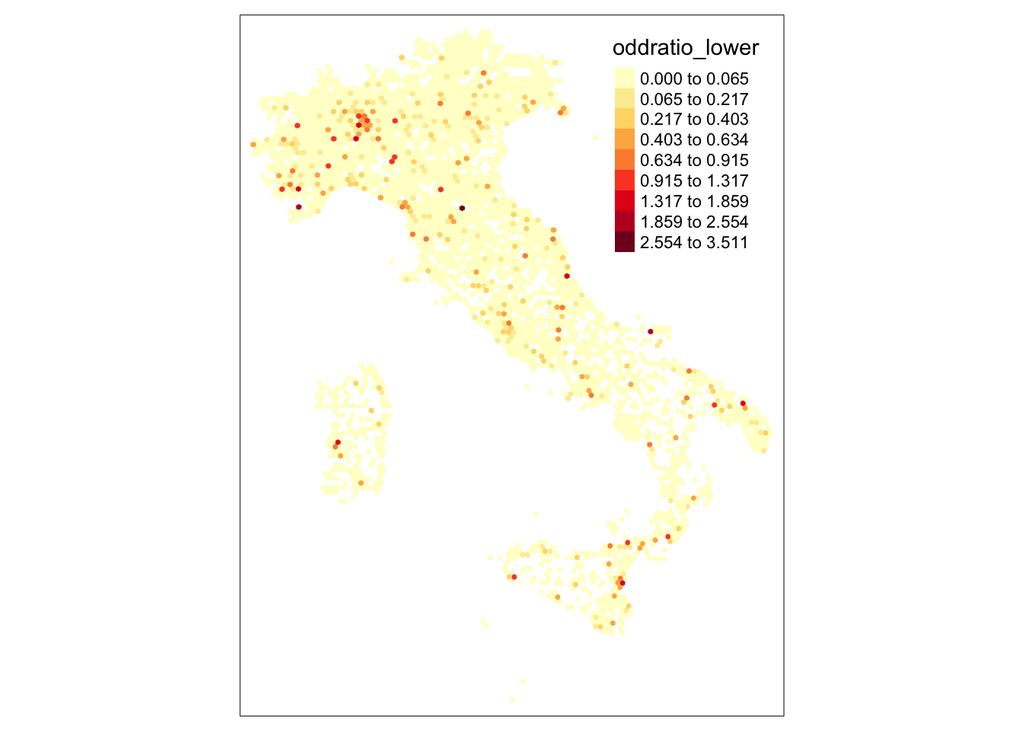

```r
# tm_shape(boundary_Italy) +
#   tm_borders() +
tm_shape(
    hex_gird %>%
      inner_join(
        barcafes_Italy_with_hex_oddratios %>%
          filter(word == "pane")
      )
  ) +
  tm_fill(
    "oddratio_lower",
    showNA = FALSE, palette = "YlOrRd", n=9, style = "jenks"
  )
```

### Forno

```r
leaflet(
    barcafes_Italy %>%
    filter(
      name %>%
        str_to_lower() %>%
        str_detect("forno")
    )
  ) %>%
  addTiles() %>%
  addProviderTiles(providers$Stamen.Toner) %>%
  addCircleMarkers(
    radius = 5,
    color = "red",
    popup = ~as.character(name),
    label = ~as.character(name)
  )
```

[interactive chart not shown]

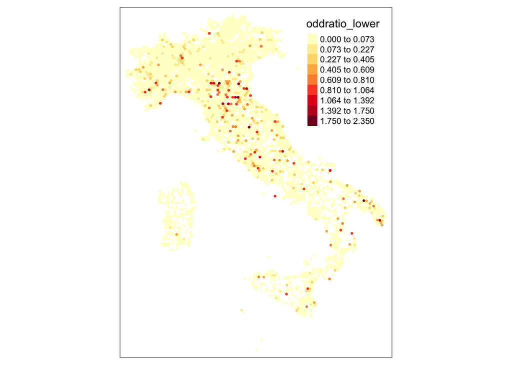

```r
# tm_shape(boundary_Italy) +
#   tm_borders() +
tm_shape(
    hex_gird %>%
      inner_join(
        barcafes_Italy_with_hex_oddratios %>%
          filter(word == "forno")
      )
  ) +
  tm_fill(
    "oddratio_lower",
    showNA = FALSE, palette = "YlOrRd", n=9, style = "jenks"
  )
```

### Centrale

```r
leaflet(
    barcafes_Italy %>%
    filter(
      name %>%
        str_to_lower() %>%
        str_detect("centrale")
    )
  ) %>%
  addTiles() %>%
  addProviderTiles(providers$Stamen.Toner) %>%
  addCircleMarkers(
    radius = 5,
    color = "red",
    popup = ~as.character(name),
    label = ~as.character(name)
  )
```

[interactive chart not shown]

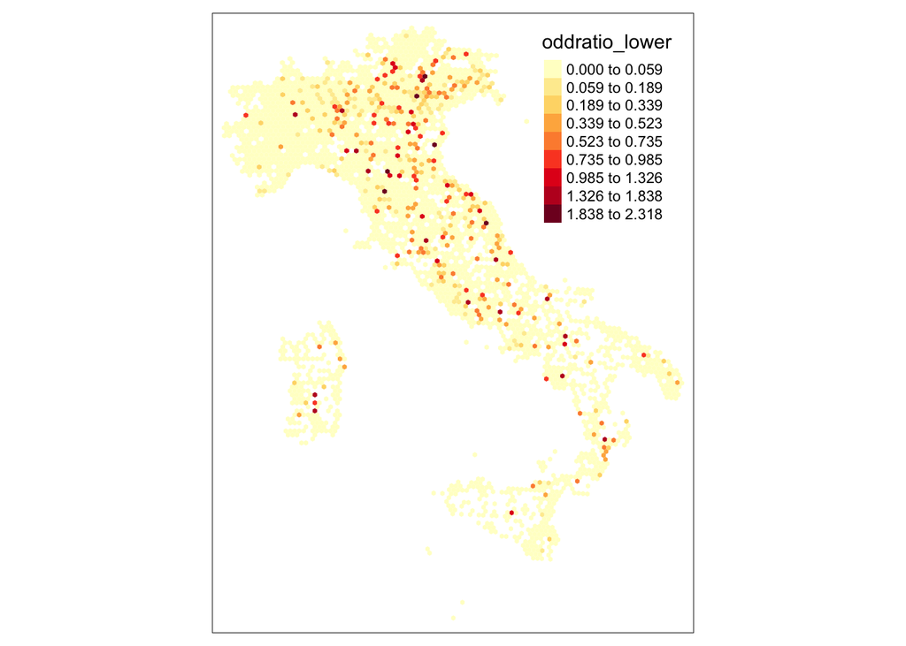

```r
# tm_shape(boundary_Italy) +
#   tm_borders() +
tm_shape(
    hex_gird %>%
      inner_join(
        barcafes_Italy_with_hex_oddratios %>%
          filter(word == "centrale")
      )
  ) +
  tm_fill(
    "oddratio_lower",
    showNA = FALSE, palette = "YlOrRd", n=9, style = "jenks"
  )
```

## References

Brunsdon, Chris, Harris, Paul, & Comber, Alexis. (2022, March 30). A Spatial Analysis of British Public House Names. 30th Annual Geographical Information Science Research UK (GISRUK), Liverpool, United Kingdom. https://doi.org/10.5281/zenodo.6410180

Shelton, T., Poorthuis, A., Graham, M., & Zook, M. (2014). Mapping the data shadows of Hurricane Sandy: Uncovering the sociospatial dimensions of ‘big data’. Geoforum, 52, 167-179. https://doi.org/10.1016/j.geoforum.2014.01.006